# Winter/Summer - stats testing

## demo that function works

```r
## plot data
#calculate difference to create mvar
smoothed_data <- smoothed_data %>%
  mutate(mvar = param - moving_avg)
```

plot - check the smoother makes sense and tweak values if they dont line plot can be added to the app - show pre pandemic and post pandemic in different plots in this plot seasonal var much greater than long term var

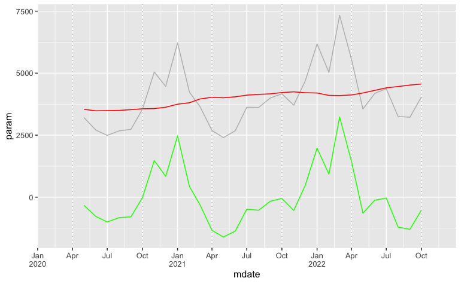

```r
plotlim <- as.Date(c("2020-01-01","2022-12-31"))
smoothed_data %>%
ggplot() +
  #geom_line(aes(x = mdate, y = c(param, moving_avg, mvar)))
  #above is an attempt to merge them - doesnt work!
  geom_line(aes(x = mdate, y = param), colour = "gray") +
  geom_line(aes(x = mdate, y = moving_avg), colour = "red") +
  geom_line(aes(x = mdate, y = mvar), colour = "green") +
  scale_x_date(limits=plotlim, date_breaks="3 month",
               labels = scales::label_date_short(), expand = c(0,0)) +
    # add dashed lines to show the boundaries
    geom_vline(xintercept=ymd(20201001),color="gray",linetype="dotted", linewidth = 0.5) +
    geom_vline(xintercept=ymd(20211001),color="gray",linetype="dotted", linewidth = 0.5) +
    geom_vline(xintercept=ymd(20221001),color="gray",linetype="dotted", linewidth = 0.5) +
    geom_vline(xintercept=ymd(20200401),color="gray",linetype="dotted", linewidth = 0.5) +
    geom_vline(xintercept=ymd(20210401),color="gray",linetype="dotted", linewidth = 0.5) +
    geom_vline(xintercept=ymd(20220401),color="gray",linetype="dotted", linewidth = 0.5)
```

#now create a boxplot this box plot will be added to the app

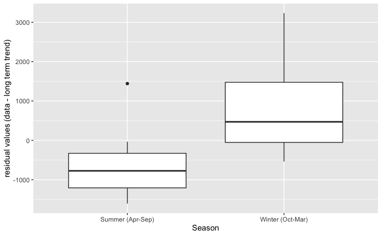

```r
smoothed_data %>%
  ggplot() +
  aes(x=iswinter, y=mvar) +
  geom_boxplot() +
  ylab("residual values (data - long term trend)") +
  xlab("Season") +
  scale_x_discrete(
    labels=c("FALSE" = "Summer (Apr-Sep)", "TRUE" = "Winter (Oct-Mar)"),
    limits = c("FALSE","TRUE"))
```

### Hypothesis Test

Is summer is significantly different to winter?

The null hypothesis is that the average value for summer is the same as the average value for winter. The alternative hypothesis is that winter was significantly higher

H0 : mean winter - mean summer <=0 HA : mean winter - mean summer > 0

we are setting alpha for this test to be 0.05

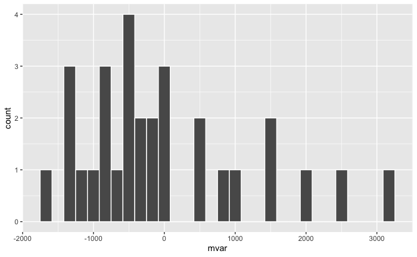

```r
smoothed_data %>%
  ggplot() +
  aes(x = mvar) +
  geom_histogram(col = "white")
```

[figure not shown]

```r
smoothed_data %>%
  ggplot() +
  aes(x = mvar) +
  geom_histogram(col = "white")
```

```r
seasonal_avg <- smoothed_data  %>%
  group_by(iswinter) %>%
  summarise(mean= mean(mvar, na.rm=TRUE))

seasonal_avg
```

| iswinter | mean |
| --- | --- |
| FALSE | -652.2753 |
| TRUE | 798.3446 |

```r
observed_stat = seasonal_avg$mean[seasonal_avg$iswinter ==TRUE]
            -seasonal_avg$mean[seasonal_avg$iswinter ==FALSE]
```

```
[1] 652.2753
```

```r
null_distribution <- smoothed_data  %>%
  specify(response = mvar, explanatory = iswinter) %>%
  hypothesize(null = "independence") %>%
  generate(reps = 1000, type = "permute") %>%
  calculate(stat = "diff in means", order = c(TRUE,FALSE)) #winter - summer
```

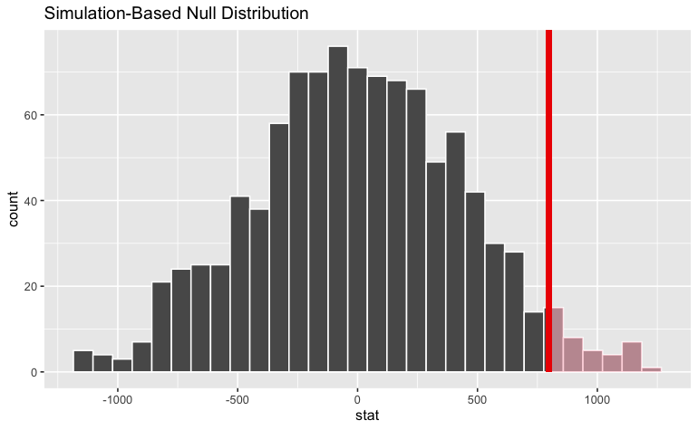

```r
null_distribution %>%
  visualise(bins = 30) +
shade_p_value(obs_stat = observed_stat
            , direction = "greater")
```

```r
p_value <- null_distribution %>%
get_p_value(obs_stat = observed_stat
            , direction = "greater") %>%
pull()
```

```r
p_value
```

```
[1] 0.039
```

If pvalue is less than alpha we can reject null hypothesis If pvalue is greater than alpha we cannot reject null hypothesis

In this case the p_value of 0.039 is less than 0.05. This means that we can reject the null hypothesis in favour of the alternative hypothesis. We can say that the two samples means are significantly different to each other. We can therefore say that for this dataste the winter values are significantly higher than teh summer values.

```r
if(p_value > alpha_test){
 print("We cannot reject the null hypothesis. The average winter values in
       this data are the same as the average summer values")
}else{
    print("We can reject the null hypothesis in favour of the alternative
          hypothesis. The average winter values in this data are
          significantly different to the average winter values")}
```

```
[1] "We can reject the null hypothesis in favour of the alternative \n          hypothesis. The average winter values in this data are \n          significantly different to the average winter values"
```